# Manhattan Property Sales Analysis

## Sale Price and Residential Units

To test the hypothesis of:  
*H1: Sale price increases with the increase of the number of residential units.*  
*H0: The number of residential units does not impact the sale price.*

**Results:** From the result, as the p-value is small, and t-value is relatively large, we could reject the null hypothesis. And from the coefficient, we could see that sale price does increase with the increase of the number of residential units.

```r
mod8 <- lm(`SALE PRICE` ~ `RESIDENTIAL UNITS`, data = manhattan_pred)
summary(mod8)
```

```
##
## Call:
## lm(formula = `SALE PRICE` ~ `RESIDENTIAL UNITS`, data = manhattan_pred)
##
## Residuals:
##        Min         1Q     Median         3Q        Max
## -175897982   -2542433   -2042433   -1022433 2152127567
##
## Coefficients:
##                     Estimate Std. Error t value Pr(>|t|)
## (Intercept)          2872433     217415   13.21   <2e-16 ***
## `RESIDENTIAL UNITS`   289825      14316   20.25   <2e-16 ***
## ---
## Signif. codes:  0 '***' 0.001 '**' 0.01 '*' 0.05 '.' 0.1 ' ' 1
##
## Residual standard error: 25930000 on 14410 degrees of freedom
## Multiple R-squared:  0.02766,    Adjusted R-squared:  0.02759
## F-statistic: 409.9 on 1 and 14410 DF,  p-value: < 2.2e-16
```

**Regression Diagnosis Plot**

From the diagnosis plot, there are quite a lot of outliers which are influencing the result of the model.

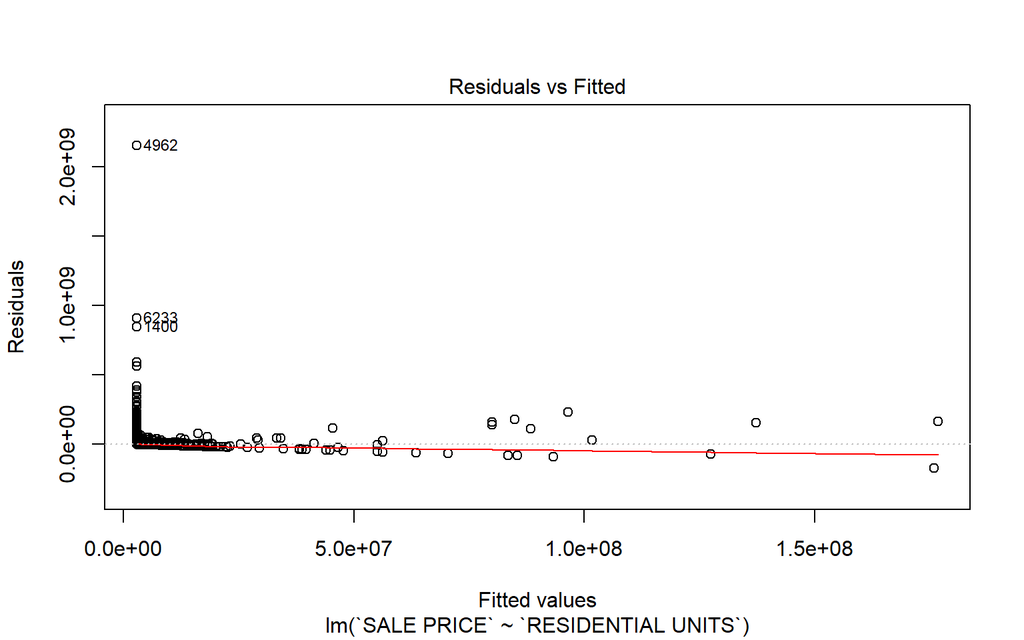

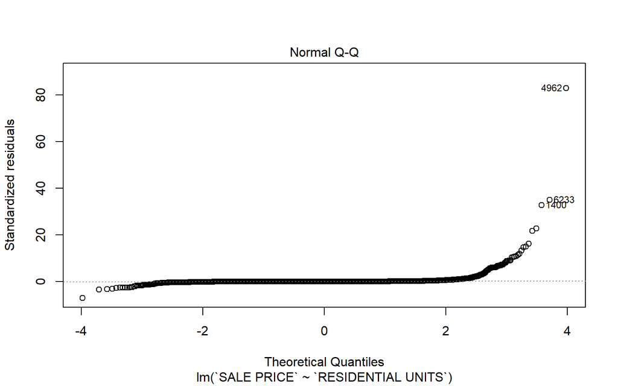

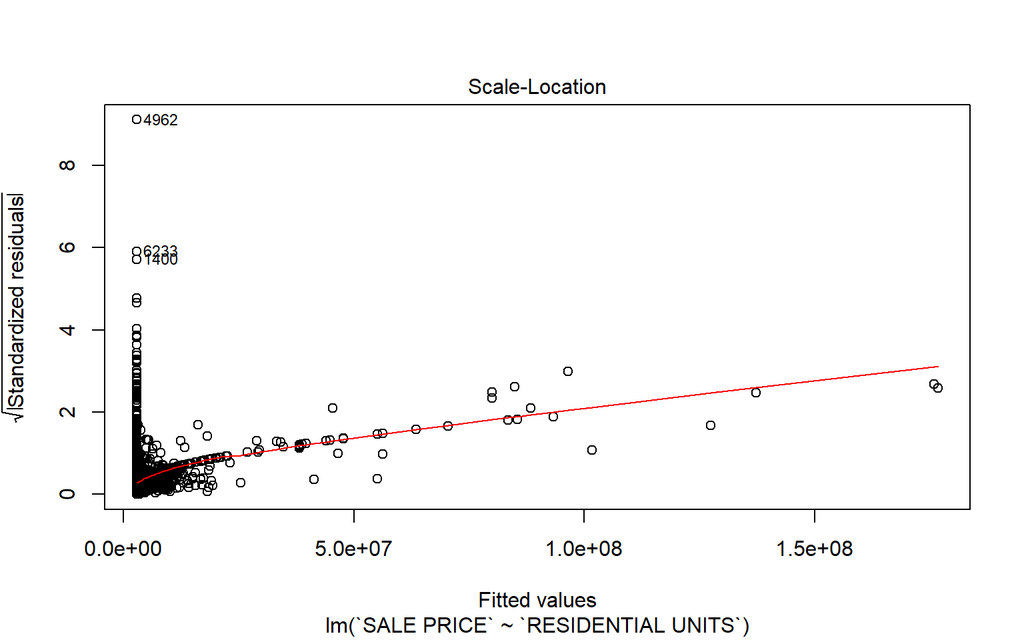

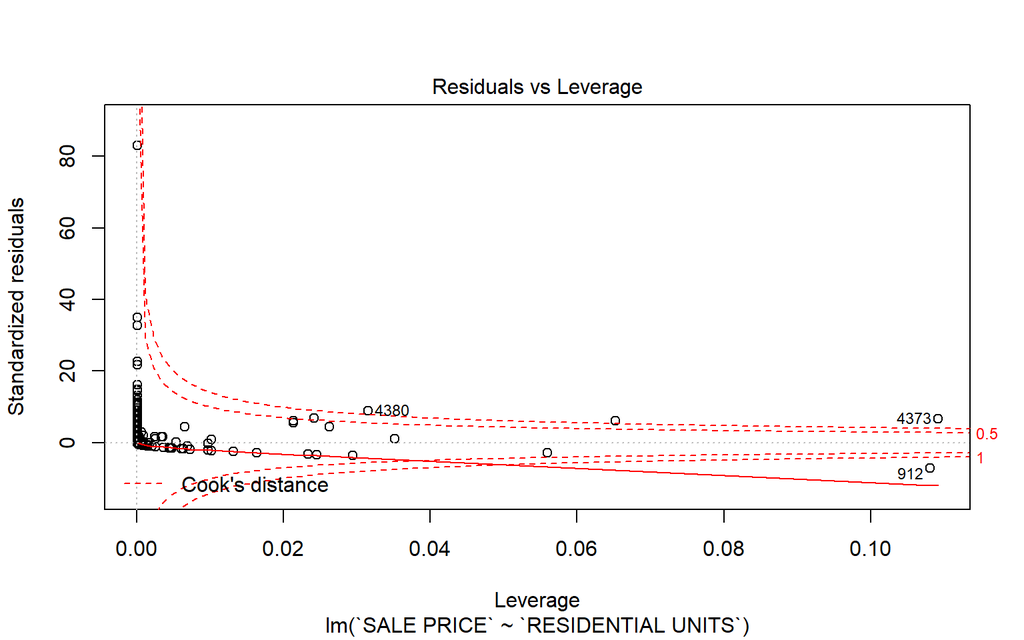

```r
#outlier
plot(mod8)
```

**Post Hoc Power Analysis:**

The sample size is sufficiently enough.

```r
#power analysis
f2value5 = 0.02759  / (1-0.02759 )
f2value5
```

```
## [1] 0.02837281
```

```r
fpower5 = pwr.f2.test(u = 1, v = 14410, f2 = f2value5, power = NULL)
fpower5
```

```
##
##      Multiple regression power calculation
##
##               u = 1
##               v = 14410
##              f2 = 0.02837281
##       sig.level = 0.05
##           power = 1
```

## Sale Price and Total Units

To test the hypothesis of:  
*H1: Sale price increases with the increase of the number of total units.*  
*H0: The number of total units does not impact the sale price.*

**Results:**From the result, as the p-value is small, and t-value is relatively large, we could reject the null hypothesis. And from the coefficient, we could see that sale price does increase with the increase of the number of total units.

```r
mod9 <- lm(`SALE PRICE` ~ `TOTAL UNITS`, data = manhattan_pred)
summary(mod9)
```

```
##
## Call:
## lm(formula = `SALE PRICE` ~ `TOTAL UNITS`, data = manhattan_pred)
##
## Residuals:
##        Min         1Q     Median         3Q        Max
## -200939165   -2341731   -1829481    -824481 2152350519
##
## Coefficients:
##               Estimate Std. Error t value Pr(>|t|)
## (Intercept)    2649481     215780   12.28   <2e-16 ***
## `TOTAL UNITS`   329933      12588   26.21   <2e-16 ***
## ---
## Signif. codes:  0 '***' 0.001 '**' 0.01 '*' 0.05 '.' 0.1 ' ' 1
##
## Residual standard error: 25690000 on 14410 degrees of freedom
## Multiple R-squared:  0.04551,    Adjusted R-squared:  0.04544
## F-statistic:   687 on 1 and 14410 DF,  p-value: < 2.2e-16
```

**Regression Diagnosis Plot**

From the diagnosis plot, there are quite a lot of outliers which are influencing the result of the model.

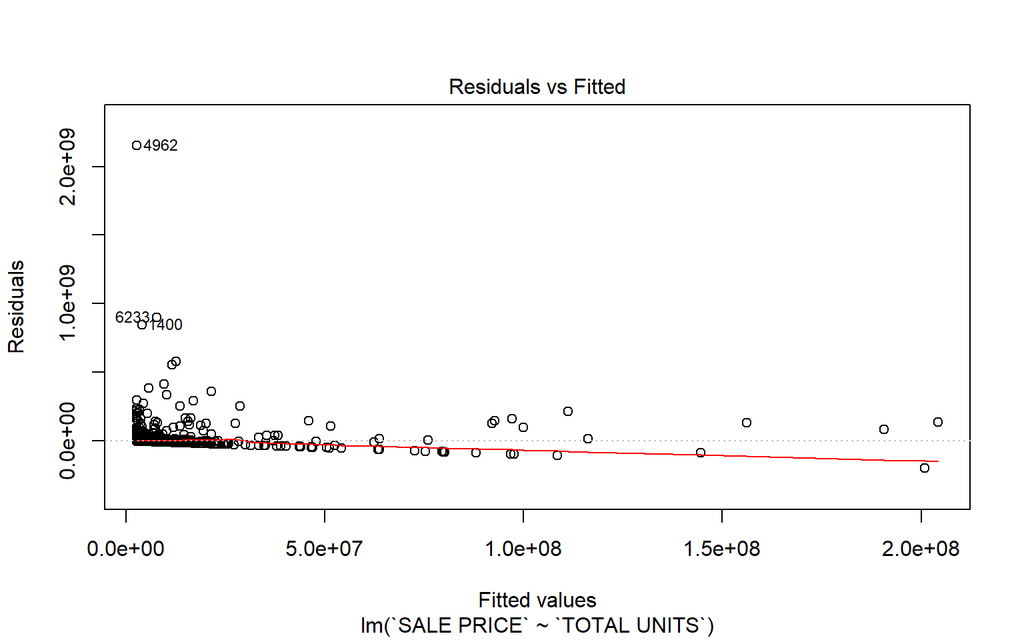

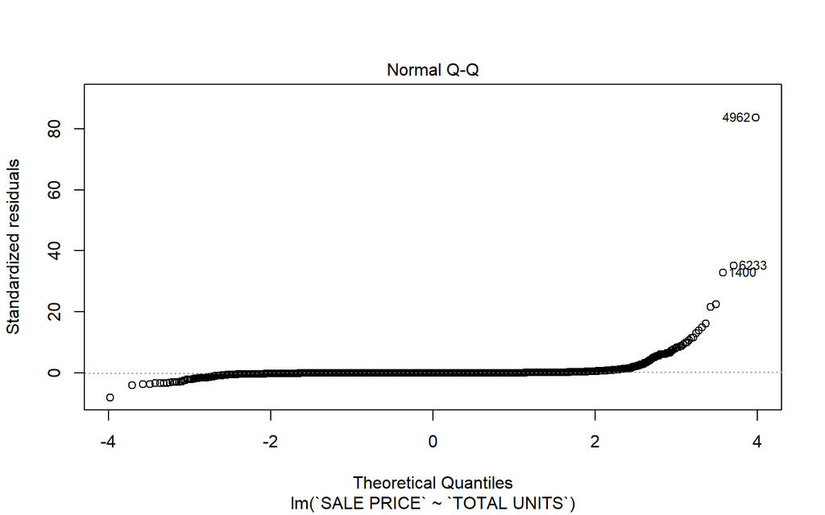

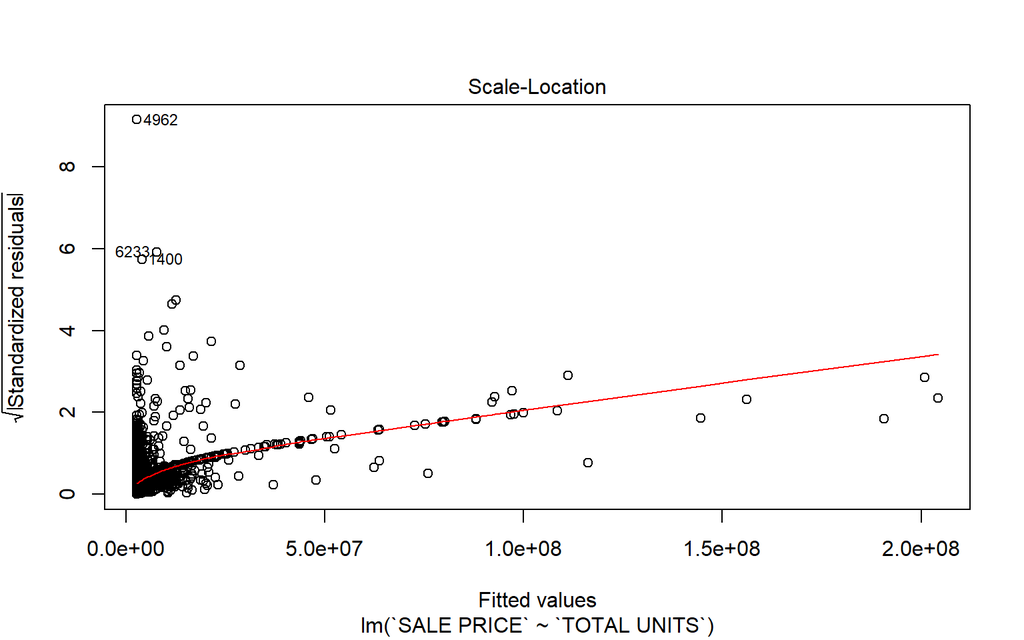

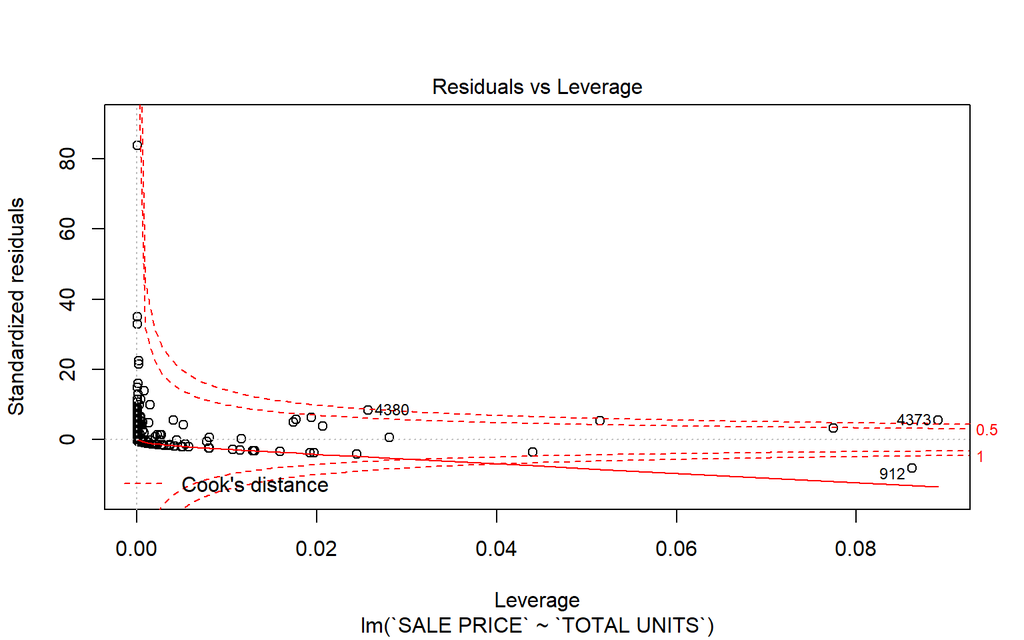

```r
#outlier
plot(mod9)
```

**Post Hoc Power Analysis:**

The sample size is sufficiently enough.

```r
#power analysis
f2value6 = 0.04544  / (1-0.04544 )
f2value6
```

```
## [1] 0.04760308
```

```r
fpower6 = pwr.f2.test(u = 1, v = 14410, f2 = f2value6, power = NULL)
fpower6
```

```
##
##      Multiple regression power calculation
##
##               u = 1
##               v = 14410
##              f2 = 0.04760308
##       sig.level = 0.05
##           power = 1
```

## Comparison of Residential Units and Commericial Units and Total Unitss Impact on Sale Price

From this comparison, we could see that all three variables have positive influence on the sale price. The number of commercial units though, have the largest impact in terms of scale, on the sale price.

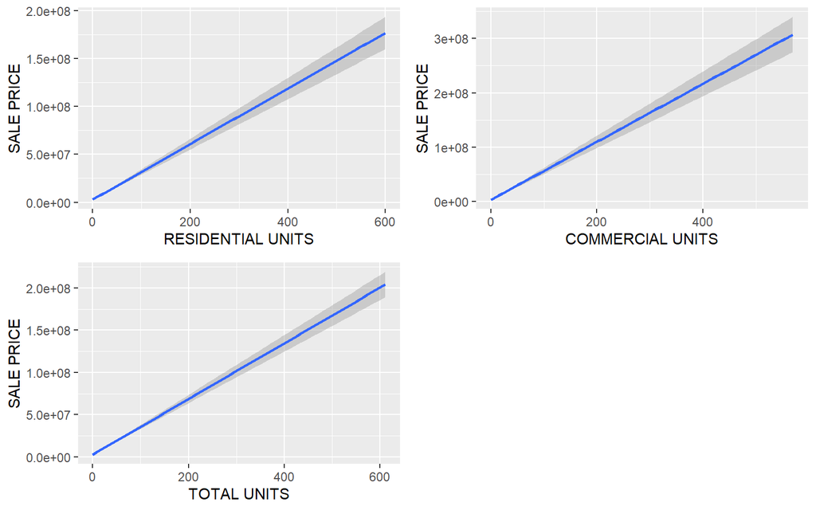

```r
ppp1 <- ggplot(manhattan_pred) +
  geom_smooth(method = lm, aes(`RESIDENTIAL UNITS`, `SALE PRICE`))

ppp2 <- ggplot(manhattan_pred) +
  geom_smooth(method = lm, aes(`COMMERCIAL UNITS`, `SALE PRICE`))

ppp3 <- ggplot(manhattan_pred) +
  geom_smooth(method = lm, aes(`TOTAL UNITS`, `SALE PRICE`))

# Put all three plots altogether.
grid.arrange(ppp1, ppp2, ppp3, nrow =2)
```

# Conclusion

Given all information gathered from the analyses, the sale price of a certain property in Manhattan is a complicated issue to look at, as it is influenced by a bunch of variables, simultaneously and towards different directions. Some interesting findings are:  
1. As many people would think that there is a certain “hot” season for property sales while there is also a “cold” season - the time of the sale, when tested on a monthly basis, do not really align with the significant differences seen in the sale price. But two outstanding time periods are February and June, judged solely from the data of last year.  
2. Many would think the gross square feet as the more critical predictor as compared with land square feet - because there are just so many high-rises across the Manhattan Island. However, the latter actually has a bigger influence on the final sale prices of properties.  
3. The ages of buildings do not have significant impact on the sale price. This might appear counter-intuitive as Manhattan property market is one that truly values older buildings (a.k.a the pre-war ones). However, since the result delivers the message that building age does not influence the sale price as much as people would assume, this might be due to the fact that most of the truly old buildings are barely seen available on market. So the data set that this analysis is based on includes most of the buidlings that are more recently constructed.  
4. It is interesting to find out that the number of commercial units has bigger impact on the sale price, as opposed to the impact from the number of total units and the number of residential units. This might be due to that the “return on investment”, ROI, from the commerical units are higher than the ROI from the residential units.  
5. Tax class really does matter when it comes to the finalized sale price - perhaps it is because of tax class indicates information such as the building class category that a certain property falls under.

# Limitation and Possible Improvement

One limitation is that this dataset is comparatively large and with quite a few variables depicting the observations from various aspects - some might consider this as an advantage though. Doing analysis based on a large dataset could make test results more robust. But it could also add on difficulties of finding detailed and intriguing patterns. Thus, focusing more on one specific area for the analysis would be more effective in some senses: what about an analysis on the property market in Chelsea neighborhood only? Or, what about an analysis on the residential properties only? Or, what about an analysis on the properties that were relatively more newly-built - say, something that was built after 2000.  
Better conversions and management of the data could also be conducted in the pre-processing phase. For example, for variable “Building Class Category”, there are over 40 classes. Thus, finding a way to better organize these classes might do good to the analysis looking at the bigger picture.  
Since the big conclusion is that the sale price could not be determined by solely one variable, buidling a predictive model that takes in all of those variables that matter would be the next step. Another area of improvement might be creating training dataset and test dataset for more in-depth study. And for models of this kind of complexity, certain test that helps with feature selection such as the LASSO test could be conducted.

# Note

Some codes, especially in the data exploration part are not executed - so as the result would not impact the overall output of this document. They are kept in the chuncks for future reference. But since they are for exploration purposes, not executing them would not affect the final outcomes included in this report.

Katherine Li

12/17/2019